# Fraud_Detection_in_Online_Payments_with_ML

1. Data Preparation

Importing essential libraries for data analysis and modeling

```python
#padas are imported for manipulation of data and handling structures datasets

import pandas as pd

#For numerical operations and arraybased computations NumPy got imported
import numpy as np

#Seaborn and Matplotlib is used for VISUALIZING THE DATA toc exploring patterns and results
import matplotlib.pyplot as plt
import seaborn as sns
```

**Importing dataset of online fraud dectection**

```python
# Load the CSV file of payments fraud detection dataset
data = pd.read_csv('PS_20174392719_1491204439457_log.csv')
```

```python
data
```

|  | step | type | amount | nameOrig | oldbalanceOrg | newbalanceOrig | nameDest | oldbalanceDest | newbalanceDest | isFraud | isFlaggedFraud |
| --- | --- | --- | --- | --- | --- | --- | --- | --- | --- | --- | --- |
| 0 | 1 | PAYMENT | 9839.64 | C1231006815 | 170136.00 | 160296.36 | M1979787155 | 0.00 | 0.00 | 0 | 0 |
| 1 | 1 | PAYMENT | 1864.28 | C1666544295 | 21249.00 | 19384.72 | M2044282225 | 0.00 | 0.00 | 0 | 0 |
| 2 | 1 | TRANSFER | 181.00 | C1305486145 | 181.00 | 0.00 | C553264065 | 0.00 | 0.00 | 1 | 0 |
| 3 | 1 | CASH_OUT | 181.00 | C840083671 | 181.00 | 0.00 | C38997010 | 21182.00 | 0.00 | 1 | 0 |
| 4 | 1 | PAYMENT | 11668.14 | C2048537720 | 41554.00 | 29885.86 | M1230701703 | 0.00 | 0.00 | 0 | 0 |
| ... | ... | ... | ... | ... | ... | ... | ... | ... | ... | ... | ... |
| 6362615 | 743 | CASH_OUT | 339682.13 | C786484425 | 339682.13 | 0.00 | C776919290 | 0.00 | 339682.13 | 1 | 0 |
| 6362616 | 743 | TRANSFER | 6311409.28 | C1529008245 | 6311409.28 | 0.00 | C1881841831 | 0.00 | 0.00 | 1 | 0 |
| 6362617 | 743 | CASH_OUT | 6311409.28 | C1162922333 | 6311409.28 | 0.00 | C1365125890 | 68488.84 | 6379898.11 | 1 | 0 |
| 6362618 | 743 | TRANSFER | 850002.52 | C1685995037 | 850002.52 | 0.00 | C2080388513 | 0.00 | 0.00 | 1 | 0 |
| 6362619 | 743 | CASH_OUT | 850002.52 | C1280323807 | 850002.52 | 0.00 | C873221189 | 6510099.11 | 7360101.63 | 1 | 0 |

6362620 rows × 11 columns

provides a concise summary of a DataFrame which is in context towards the Python Pandas Library.

- The main purpose of the designed in giving us the quick overview of the structure and characteristics of your / our data. It's particulary helpful for probing the analysis of data, helping us in understanding the data what we are working with.
- With this data frame we can quickly see that which columns have missing values.
- Also, we can verify the data types that are as expected. By understanding the number of rows and columns.
- Get an idean of how much memory the DataFrame is consuming, this data.info() is more valuable tool in getting the *first look* of our data, helping us in understanding the structure and identify potential issues.

```python
data.info()
```

```
<class 'pandas.core.frame.DataFrame'>
RangeIndex: 6362620 entries, 0 to 6362619
Data columns (total 11 columns):
 #   Column          Dtype
---  ------          -----
 0   step            int64
 1   type            object
 2   amount          float64
 3   nameOrig        object
 4   oldbalanceOrg   float64
 5   newbalanceOrig  float64
 6   nameDest        object
 7   oldbalanceDest  float64
 8   newbalanceDest  float64
 9   isFraud         int64
 10  isFlaggedFraud  int64
dtypes: float64(5), int64(3), object(3)
memory usage: 534.0+ MB
```

***data.describe()*** method which is a powerful tool for quickly generating descriptive statistics that summarize the central tendency, dispersion, and shape of a dataset's distribution.

- In the statistical summary which calsulates and returns key statistical measures for numerical columns in a *Pandas DataFrame or Series*. Also provide the summary for statistics for categorical columns, through the measures differ.
- It's invaluable for initial data exploration, providing a high-level overview of the data's characetistics.

```python
data.describe()
```

|  | step | amount | oldbalanceOrg | newbalanceOrig | oldbalanceDest | newbalanceDest | isFraud | isFlaggedFraud |
| --- | --- | --- | --- | --- | --- | --- | --- | --- |
| count | 6.362620e+06 | 6.362620e+06 | 6.362620e+06 | 6.362620e+06 | 6.362620e+06 | 6.362620e+06 | 6.362620e+06 | 6.362620e+06 |
| mean | 2.433972e+02 | 1.798619e+05 | 8.338831e+05 | 8.551137e+05 | 1.100702e+06 | 1.224996e+06 | 1.290820e-03 | 2.514687e-06 |
| std | 1.423320e+02 | 6.038582e+05 | 2.888243e+06 | 2.924049e+06 | 3.399180e+06 | 3.674129e+06 | 3.590480e-02 | 1.585775e-03 |
| min | 1.000000e+00 | 0.000000e+00 | 0.000000e+00 | 0.000000e+00 | 0.000000e+00 | 0.000000e+00 | 0.000000e+00 | 0.000000e+00 |
| 25% | 1.560000e+02 | 1.338957e+04 | 0.000000e+00 | 0.000000e+00 | 0.000000e+00 | 0.000000e+00 | 0.000000e+00 | 0.000000e+00 |
| 50% | 2.390000e+02 | 7.487194e+04 | 1.420800e+04 | 0.000000e+00 | 1.327057e+05 | 2.146614e+05 | 0.000000e+00 | 0.000000e+00 |
| 75% | 3.350000e+02 | 2.087215e+05 | 1.073152e+05 | 1.442584e+05 | 9.430367e+05 | 1.111909e+06 | 0.000000e+00 | 0.000000e+00 |
| max | 7.430000e+02 | 9.244552e+07 | 5.958504e+07 | 4.958504e+07 | 3.560159e+08 | 3.561793e+08 | 1.000000e+00 | 1.000000e+00 |

```python
#We are going to check the missing values in our dataset
data.isnull().sum()
```

|  | 0 |
| --- | --- |
| step | 0 |
| type | 0 |
| amount | 0 |
| nameOrig | 0 |
| oldbalanceOrg | 0 |
| newbalanceOrig | 0 |
| nameDest | 0 |
| oldbalanceDest | 0 |
| newbalanceDest | 0 |
| isFraud | 0 |
| isFlaggedFraud | 0 |

**dtype:** int64

```python
#We are going to find the duplicates values if it is present in the dataset
data.duplicated().sum()
```

```
np.int64(0)
```

```python
#iterating each column to count occurances of null values
for i in data.columns:
  print(i)
  print(data[i][data[i].isnull()==True].count())
```

```
step
0
type
0
amount
0
nameOrig
0
oldbalanceOrg
0
newbalanceOrig
0
nameDest
0
oldbalanceDest
0
newbalanceDest
0
isFraud
0
isFlaggedFraud
0
```

```python
#Iterate through each column to count occurrences of zero values
for col in data.columns:
  print(f"Zero values in {col}: {(data[col] == 0).sum()}")
```

```
Zero values in step: 0
Zero values in type: 0
Zero values in amount: 16
Zero values in nameOrig: 0
Zero values in oldbalanceOrg: 2102449
Zero values in newbalanceOrig: 3609566
Zero values in nameDest: 0
Zero values in oldbalanceDest: 2704388
Zero values in newbalanceDest: 2439433
Zero values in isFraud: 6354407
Zero values in isFlaggedFraud: 6362604
```

```python
# Removing the transactions with zero amounts as they represent redundant or invalid entries
data = data[data['amount'] != 0]
print(data)
#This is also another way to remove transactions with zero amounts as they are going to represent redudndant or enteries that are invalid
#data=data[data['amount'] > 0].copy()
```

```
         step      type      amount     nameOrig  oldbalanceOrg  \
0           1   PAYMENT     9839.64  C1231006815      170136.00
1           1   PAYMENT     1864.28  C1666544295       21249.00
2           1  TRANSFER      181.00  C1305486145         181.00
3           1  CASH_OUT      181.00   C840083671         181.00
4           1   PAYMENT    11668.14  C2048537720       41554.00
...       ...       ...         ...          ...            ...
6362615   743  CASH_OUT   339682.13   C786484425      339682.13
6362616   743  TRANSFER  6311409.28  C1529008245     6311409.28
6362617   743  CASH_OUT  6311409.28  C1162922333     6311409.28
6362618   743  TRANSFER   850002.52  C1685995037      850002.52
6362619   743  CASH_OUT   850002.52  C1280323807      850002.52

         newbalanceOrig     nameDest  oldbalanceDest  newbalanceDest  isFraud  \
0             160296.36  M1979787155            0.00            0.00        0
```

[output cut: 25 more lines]

- By filtering out zero-amount transactions, we've made better quality for our data, making it fitting for deeper investigation.
- In our next steps, we are going to analyze the unique entries in ***'type', 'isFraud', 'isFlaggedFraud'*** as in going to recognize their numerous categories and distributions, which is going to help us in exploring **Fraud detection**.

Below are two ways in extracting the categorical columns for exploring the their distinct categories.

In Type 1 with help of for loop extracted the unique values

```python
# Type 1: Extract unique values for categorical columna to explore their distinct categories
categorical_columns = ['type', 'isFraud', 'isFlaggedFraud']

for column in categorical_columns:
    unique_values = data[column].unique()
    print(f"Unique values in column '{column}':")
    print(unique_values)
    print()
#display the unique values for each columns
print(data['type'].unique())
print(data['isFraud'].unique())
print(data['isFlaggedFraud'].unique())
```

```
Unique values in column 'type':
['PAYMENT' 'TRANSFER' 'CASH_OUT' 'DEBIT' 'CASH_IN']

Unique values in column 'isFraud':
[0 1]

Unique values in column 'isFlaggedFraud':
[0 1]

['PAYMENT' 'TRANSFER' 'CASH_OUT' 'DEBIT' 'CASH_IN']
[0 1]
[0 1]
```

```python
# Extracting unique values for categorical columns to explore their distinct categories

unique_values_type = data['type'].unique()
unique_values_isFraud = data['isFraud'].unique()
unique_values_isFlaggedFraud = data['isFlaggedFraud'].unique()

# Display the unique values for each column
print("Unique values in 'type' column:", unique_values_type)
print("Unique values in 'isFraud' column:", unique_values_isFraud)
print("Unique values in 'isFlaggedFraud' column:", unique_values_isFlaggedFraud)
```

```
Unique values in 'type' column: ['PAYMENT' 'TRANSFER' 'CASH_OUT' 'DEBIT' 'CASH_IN']
Unique values in 'isFraud' column: [0 1]
Unique values in 'isFlaggedFraud' column: [0 1]
```

- After a careful examination of our current dataset which is revealing the presence of three columns intended to represent categorical information. while we have made progress in transforming these non-numerical features into a format that is going to suit the *Machine Learning*, a critical inconsistency persists.
- Specifically, the *'isFraud'* and *'isFlaggedFraud'* columns have been effectively converted to numerical representations, likely through techniques like *binary encoding* or similar methods.
- However, the 'TYPE' column, which categorizes transaction types, remains in its original categorical form. This difference in representation poses a potential challenge. ML Algorithms generally perform optimally with numerical inputsm and the presence of a non-numerical column can impede model training and performance.
- Hence, an important step in our data preprocessing pipelines are going to be addresed with the discrepancy by applying appropriate encoding techniques to the 'TYPE' column. This transformation will ensure uniformity across all features, enabling us to build a more robust and accurate fraud detection model.

```python
#we are going to label encoding the 'type' column since it is categorical and we need numbers for modeling
data['type']= data['type'].map({'CASH_OUT':0, 'PAYMENT':1, 'CASH_IN':2, 'TRANSFER':3, 'DEBIT':4})
#data['isFraud']= data['isFraud'].map({0:'No Fraud', 1:'Fraud'})
#data['isFlaggedFraud']= data['isFlaggedFraud'].map({0:'No Fraud', 1:'Fraud'})
```

Here we are going to examine the distribution of transaction types and inspect the number of transactions in the datasets. If we observe that an imbalance in our dataset then, we are going to address this issue using, transformation tools such as *log, robust, Synthetic Minority Over-sampling Technique (SMOTE)* for making sure to be better model performance and more accurate prediction.

**2. Exploratory Data Analysis (EDA) ON RAW DATA**

Now lets see how many fraud cases we have among all the transactions.

```python
# We are getting the value that counts for the 'isFraud' variables
isFraud_counts = data['isFraud'].value_counts()

# Display the value counts
print("Value Counts:\n",isFraud_counts)
```

```
Value Counts:
 isFraud
0    6354407
1       8197
Name: count, dtype: int64
```

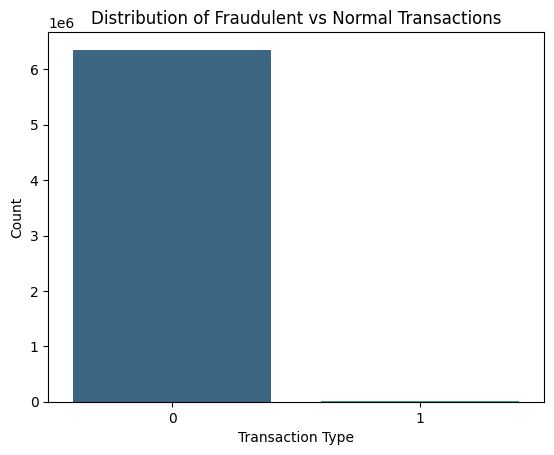

```python
#For visualizing the data we are ploting the bar or countplot that
#is between the distribution of Fraudulent vs normal distribution.
sns.countplot(x='isFraud', data=data, order=isFraud_counts.index, palette='viridis')
plt.title('Distribution of Fraudulent vs Normal Transactions')
plt.xlabel('Transaction Type')
plt.ylabel('Count')
plt.show()
```

The dataset is revealilng a substantial calss imbalance within the *'isFraud'* column, where the vast majority of transactions are non-fraudulant, a typical characterristic of fraud detection scenarios. While this imbalance presents a challenge by potentially skewing models toward predicting non-fraudulent outcomes and hindering the detection of rare fraudulent cases, we are going to postpone addressing it until after completing the *Exploratory Data Analysis (EDA)*. This dely is crucial to preserve the raw data's inherent patterns during our initial investigation. Following the EDA, we will employ techniques like *oversampling, undersampling, or classweight* adjustments to mitigate the imbalance. To accurately evaluate model performance in this context, we'll rely on metrics such as precision, recall, and the F1-score, as traditional accuracy metrics can be misleading when dealing with imbalanced dataset.

- With the goal of understanding the factors that contributes to fraudulent transactions, we will now shift our attention to the *'isFraud'* column, which serves as our critical target variables.
- This variable, indicating whether a transaction is fraudulent or not, will be the focal point of our analysis. Specifically, we aim in examining the relationships among this binary target and the remaining numerical columns withinb the dataset.
- By exploring how these numerical features vary across fraudulant and non-fraudulant transactions, we can uncover potential patterns and correlations that may be inicative of fradulant activity. This investigation will involve comparing statistical distributions, calculating correlation coefficients, and potentially visualizing these realtionships to gian a deeper understanding of the underlying dynamics and inform the development of an effective fraud detection models.
- To investigate the potential influence of transaction details on fraud, we've chosen to focus on several numerical variables: *'amount', 'oldbalanceOrg', 'newbalanceOrig', 'oldbalanceDest', and 'newbalanceDest'.* These columns, which capture the monetary value of transaction, are hypothesized to contain critical information that can differentiate between legitimate and fraudulent activitites.

```
['type', 'amount', 'oldbalanceOrg', 'newbalanceOrig', 'oldbalanceDest', 'newbalanceDest']
```

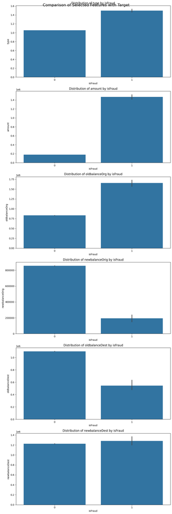

```python
#list of selected features to analyze
selected_features = ['type', 'amount', 'oldbalanceOrg', 'newbalanceOrig', 'oldbalanceDest', 'newbalanceDest']
print(selected_features)

# Create subplots (number of subplots is equal to the number of selected features)
fig, axes = plt.subplots(nrows=len(selected_features), figsize=(10, 5 * len(selected_features)))
# Loop through each selected feature to create individual bar plots
for i, feature in enumerate(selected_features):
    sns.barplot(x=data['isFraud'], y=data[feature], data=data, ax=axes[i])
    axes[i].set_title(f'Distribution of {feature} by isFraud')
    axes[i].set_xlabel('isFraud')
    axes[i].set_ylabel(feature)
# Add a title for the overall figure and adjust layout for better spacing
plt.suptitle("Comparison of Selected Features with Target", fontsize=16)
plt.tight_layout()
plt.show()
```

**Let’s check which transaction type is the most common in our dataset**

```python
#grab the value counts for the 'type' column to see the breakdown
type_counts = data['type'].value_counts()
print("Value Counts:\n",type_counts)
```

```
Value Counts:
 type
0    2237484
1    2151495
2    1399284
3     532909
4      41432
Name: count, dtype: int64
```

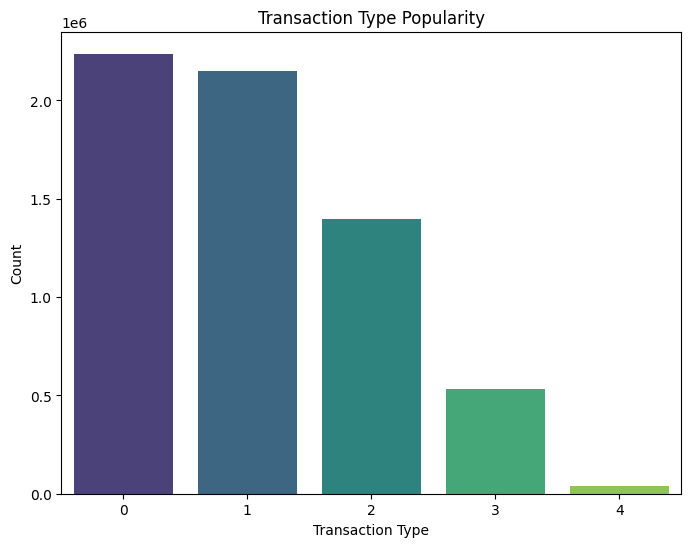

```python
#plot a count type to visualize transaction type popularity
plt.figure(figsize=(8, 6))
sns.countplot(x='type', data=data, order=type_counts.index, palette='viridis')
plt.title('Transaction Type Popularity')
plt.xlabel('Transaction Type')
plt.ylabel('Count')
plt.show()
```

Note that for 0: CASH_OUT; 1: PAYMENT; 2: CASH_IN; 3:TRANSFER; 4: DEBIT

This must be highlight which type's most frequent-pretty handy for spotting tends!

Looking at the distribution of 'type' after label encoding:

- It is pretty imbalanced- CASH_OUT and PAYMENT dominate, while DEBIT's way smaller.
- Since we are working on fraud detection and haven't changed 'type' yet, this imbalance might not hurt too much.
- If our bettrt model example something tree-based like Random Forest can handle it.
- Still, if 'type' ties closely to 'isFraud' and we see skew in predictions later,

we could balance it with oversampling (SMOTE) or undersampling—just not right now during EDA.

**so as we saw on graph only two transation type is most used so now we will examine that is that in which type of transaction fraud occured the most.**

```python
#create a  contingency table (cross-tabulation) between isFraud and type
contingency_table = pd.crosstab(data['isFraud'], data['type'])
print(contingency_table)
```

```
type           0        1        2       3      4
isFraud
0        2233384  2151495  1399284  528812  41432
1           4100        0        0    4097      0
```

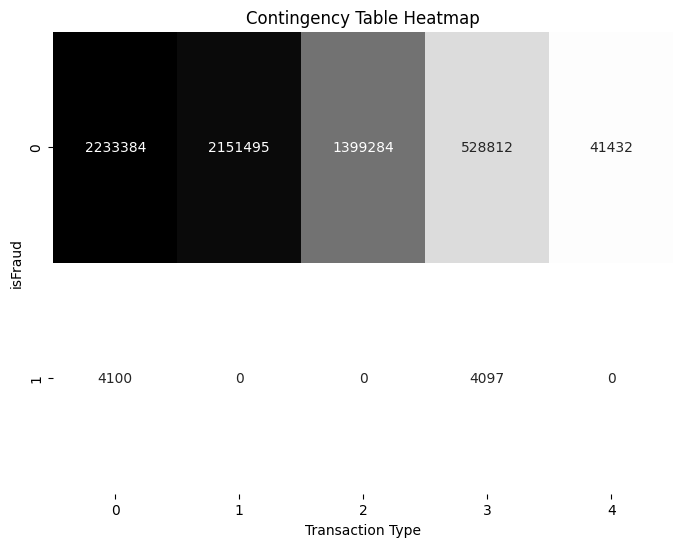

```python
# Plot heatmap for the contingency table
plt.figure(figsize=(8, 6))
sns.heatmap(contingency_table, annot=True, fmt='d', cmap='Greys', cbar=False)
plt.title('Contingency Table Heatmap')
plt.xlabel('Transaction Type')
plt.ylabel('isFraud')
plt.show()
```

**PART 3: Feature Engineering**

**Focusing on Fraud-Prone Transaction Types.**

Our analysis reveals a striking pattern: All instances of fraud within the dataset are confines to just two transaction categories, **'cashout' and 'transfer'**, with roughly equal occurances. Notably, the remaining transaction types- ***'payment', 'debit', and 'cash_in'*** - show no evidance of fraudulant activity. This Concentrated occurences suggets that fraudsters specifically target ***'cashout' and 'transfer'*** transactions, likely due to the enhanced ability these methods provide to rapidly move illicit funds either out of the system or between accounts, thus facilitating their criminal objectives.

```python
#We are going to define the weights with our transaction types by using numeric values
transaction_type_weights = {
    0: 2.0,  # CASH_OUT
    1: 1.0,  # PAYMENT
    2: 1.0,  # CASH_IN
    3: 2.0, # TRANSFER
    4: 1.0  # DEBIT
}
#For missing categories we are assigining the weights with default values.
data['transaction_type_weight'] = data['type'].map(lambda x: transaction_type_weights.get(x, 1.0))
print(data['transaction_type_weight'])
```

```
0          1.0
1          1.0
2          2.0
3          2.0
4          1.0
          ...
6362615    2.0
6362616    2.0
6362617    2.0
6362618    2.0
6362619    2.0
Name: transaction_type_weight, Length: 6362604, dtype: float64
```

The ***exploratory data analysis (EDA)** * process is being hampered by the data's significant skewness and the presence of numerous outliers, making effective visualization challenging. To address these issues and facilitate clearer data analysis, a normalization strategy will be implemented.

Specifically, the 'amount' columns, which is particularly susceptible to outliers, will be transformed using *RobustScaler,* a techniwue designed to mitigate the impact of extreme values. For the remaining numerical columns, a logarithmic transformation will be applied. This approach will reduce skewness, resulting in a more symmetrical data distribution and consequently, improving the clarity and interpretability of visualizations during EDA phase.

```python
from sklearn.preprocessing import RobustScaler, MinMaxScaler, StandardScaler


# Initializing the  scalers
robust_scaler = RobustScaler()

# Transformations are applied here
data['amount_scaled'] = robust_scaler.fit_transform(data[['amount']])

# Log transformations are applied in preventing the dominance of zero]
data['oldbalanceOrg_log'] = np.log1p(data['oldbalanceOrg'])
data['newbalanceOrig_log'] = np.log1p(data['newbalanceOrig'])
data['oldbalanceDest_log'] = np.log1p(data['oldbalanceDest'])
data['newbalanceDest_log'] = np.log1p(data['newbalanceDest'])

#Printing the data that is scaled
print(data[['amount_scaled', 'oldbalanceOrg_log', 'newbalanceOrig_log',
                        'oldbalanceDest_log', 'newbalanceDest_log']].describe())
```

```
       amount_scaled  oldbalanceOrg_log  newbalanceOrig_log  \
count   6.362604e+06       6.362604e+06        6.362604e+06
mean    5.374923e-01       7.414592e+00        5.366105e+00
std     3.091448e+00       5.669751e+00        6.330027e+00
min    -3.833107e-01       0.000000e+00        0.000000e+00
25%    -3.147621e-01       0.000000e+00        0.000000e+00
50%     0.000000e+00       9.561672e+00        0.000000e+00
75%     6.852379e-01       1.158354e+01        1.187937e+01
max     4.728903e+02       1.790292e+01        1.771920e+01

       oldbalanceDest_log  newbalanceDest_log
count        6.362604e+06        6.362604e+06
mean         7.722419e+00        8.330605e+00
std          6.747638e+00        6.675096e+00
min          0.000000e+00        0.000000e+00
25%          0.000000e+00        0.000000e+00
50%          1.179590e+01        1.227682e+01
75%          1.375686e+01        1.392159e+01
max          1.969049e+01        1.969094e+01
```

***Analyzing Fraud Rates by Transaction Amount Bins***

For understaning the fraud varies across different transaction amounts, I binned the amount columns into predefined ranges and calculated the fraud rate for each bins. This is going to help in recognizing which transactions amounts that are most susceptible fraud.

```python
#defining amount bins and labels
amount_bins = [0, 100, 500, 1000, 5000, 10000, 50000, 100000, 1000000, float('inf')]
#define labels
amount_labels = ['0-100', '100-500', '500-1K', '1K-5K', '5K-10K', '10K-50K', '50K-100K', '100K+', '1000K+']
#Bin the transaction amounts
data['amount_binned'] = pd.cut(data['amount'], bins=amount_bins, labels=amount_labels)
```

```python
#calculated fraud rate per bin in a seperate dataframe also add the renaming of the columns of count and sum
fraud_rate_per_bin = data.groupby('amount_binned')['isFraud'].agg(['count', 'sum']).rename(columns={'count': 'Total_Transaction_Count', 'sum': 'Fraud_Transaction_Count'})
#do average for the Fraud_Transaction_Count and Total_Transaction_Count
fraud_rate_per_bin['Fraud_Rate'] = fraud_rate_per_bin['Fraud_Transaction_Count'] / fraud_rate_per_bin['Total_Transaction_Count']


#reset the index for readability
fraud_rate_per_bin = fraud_rate_per_bin.reset_index()

print(fraud_rate_per_bin)
```

```
  amount_binned  Total_Transaction_Count  Fraud_Transaction_Count  Fraud_Rate
0         0-100                    14089                        2    0.000142
1       100-500                    56987                       34    0.000597
2        500-1K                    71554                        6    0.000084
3         1K-5K                   559855                      104    0.000186
4        5K-10K                   583590                      116    0.000199
5       10K-50K                  1519856                      760    0.000500
6      50K-100K                   719351                      669    0.000930
7         100K+                  2706696                     3800    0.001404
8        1000K+                   130626                     2706    0.020716
```

***Assigning Weights to Transaction Amount Bins***

To enhance the model's ability to detect fraud within critical transaction value ranges, a weighting system was implemented based on 'amount_bin' categories. Bins representing higher transaction amoounts, specifically those those exceeding 100,000 and 1,000,000, were assigned significantly greater weights. This strategic weighting ensures that the model places a higher emphasis on learning patterns associated with these high-value transactions, thereby improving its performance in identifying high-risk fraudulent activities.

```python
#define weights for each transaction amount bin
amount_bin_weights = {
    '0-100': 1.0,
    '100-500': 1.0,
    '500-1K': 1.0,
    '1K-5K': 1.0,
    '5K-10K': 1.0,
    '10K-50K': 1.0,
    '50K-100K': 1.0,
    '100K+': 1.5,
    '1000K+': 2.0
}
```

With the dataset now thoroughly prepared through cleaning, filtering, and transformations, we will proceed to employ visual analysis techniques to uncover underlying patterns and pinpoint the areas where fraudulent activity is most concentrated. This visual exploration aims to elucidate the specific features or conditions that exhibit a strong correlation with fraudulent transactions, providing valuable insights into the characteristics that distinguish them from legitimate transactions.

```python
#assign bin weights to the data dataframes
data['amount_bin_weight'] = data['amount_binned'].map(lambda x: amount_bin_weights.get(x, 1.0))
print(data['amount_bin_weight'])
```

```
0          1.0
1          1.0
2          1.0
3          1.0
4          1.0
          ...
6362615    1.5
6362616    2.0
6362617    2.0
6362618    1.5
6362619    1.5
Name: amount_bin_weight, Length: 6362604, dtype: float64
```

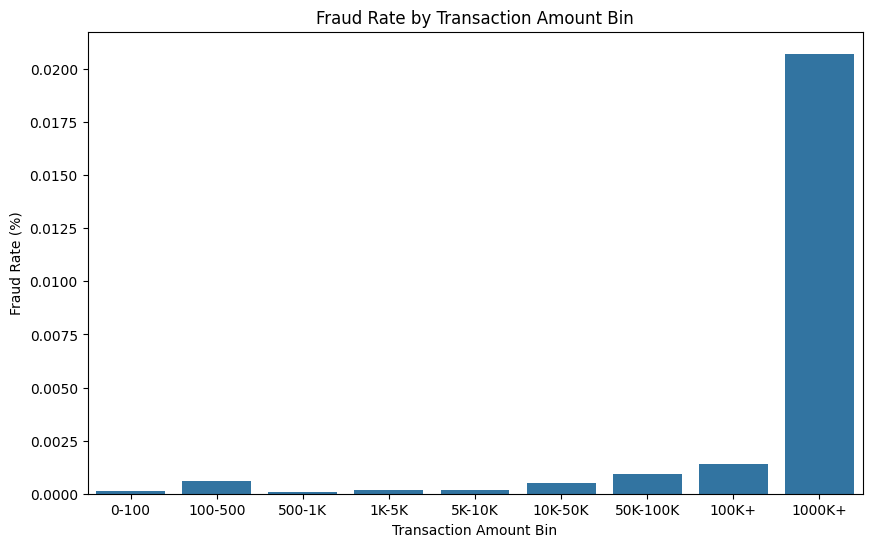

```python
#plot
plt.figure(figsize=(10, 6))
sns.barplot(x='amount_binned', y='Fraud_Rate', data=fraud_rate_per_bin)
plt.title('Fraud Rate by Transaction Amount Bin')
plt.xlabel('Transaction Amount Bin')
plt.ylabel('Fraud Rate (%)')
```

**4. EDA on Transformed Data**

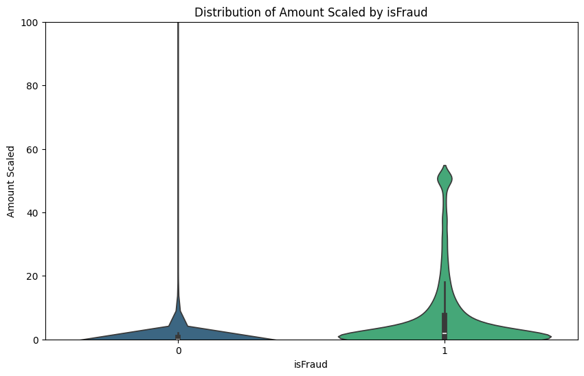

```python
#plot the graph
plt.figure(figsize=(10, 6))
sns.violinplot(x='isFraud', y='amount_scaled', data=data, palette='viridis')
plt.title('Distribution of Amount Scaled by isFraud')
plt.xlabel('isFraud')
plt.ylabel('Amount Scaled')
plt.ylim(0,100)
plt.show()
```

***For Non-Fraud(0)*** Legitimate transactions typically involve smaller monetary values and are clustered within a relatively tight rangem indicating lower variability in their amounts.

***For Fraud(1):*** Fraudulant transactions are charaterized by significantly larger monetary values, as evidanced by the higher peak in their distribution. These transactions also exhibit a broader range of values, indicating that fraudsters engage in transactions with greater variability in amounts. The overall shape of the distribution suggests a preference for higher-value transactions, though attempts are made across a wider spectrum of amounts.

A bar plot, generated using the Seaborn library, was created to visualize the relationship between transaction amount ranges and fraud rates. This plot effectively illustrates the prevalence of fraud across different transaction value brackets, allowing for a clear identification of which amount ranges are most susceptible to fraudulent activity.

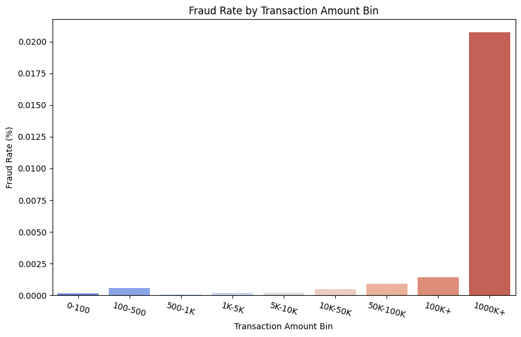

```python
import seaborn as sns
import matplotlib.pyplot as plt

#plot
plt.figure(figsize=(10, 6))
sns.barplot(x='amount_binned', y='Fraud_Rate', data=fraud_rate_per_bin, palette='coolwarm')
plt.title('Fraud Rate by Transaction Amount Bin')
plt.xlabel('Transaction Amount Bin')
plt.ylabel('Fraud Rate (%)')
plt.xticks(rotation=-15)
plt.show()
```

```python
data.head(30)
```

|  | step | type | amount | nameOrig | oldbalanceOrg | newbalanceOrig | nameDest | oldbalanceDest | newbalanceDest | isFraud | isFlaggedFraud | transaction_type_weight | amount_scaled | oldbalanceOrg_log | newbalanceOrig_log | oldbalanceDest_log | newbalanceDest_log | amount_binned | amount_bin_weight |
| --- | --- | --- | --- | --- | --- | --- | --- | --- | --- | --- | --- | --- | --- | --- | --- | --- | --- | --- | --- |
| 0 | 1 | 1 | 9839.64 | C1231006815 | 170136.00 | 160296.36 | M1979787155 | 0.0 | 0.00 | 0 | 0 | 1.0 | -0.332937 | 12.044359 | 11.984786 | 0.000000 | 0.000000 | 5K-10K | 1.0 |
| 1 | 1 | 1 | 1864.28 | C1666544295 | 21249.00 | 19384.72 | M2044282225 | 0.0 | 0.00 | 0 | 0 | 1.0 | -0.373767 | 9.964112 | 9.872292 | 0.000000 | 0.000000 | 1K-5K | 1.0 |
| 2 | 1 | 3 | 181.00 | C1305486145 | 181.00 | 0.00 | C553264065 | 0.0 | 0.00 | 1 | 0 | 2.0 | -0.382384 | 5.204007 | 0.000000 | 0.000000 | 0.000000 | 100-500 | 1.0 |
| 3 | 1 | 0 | 181.00 | C840083671 | 181.00 | 0.00 | C38997010 | 21182.0 | 0.00 | 1 | 0 | 2.0 | -0.382384 | 5.204007 | 0.000000 | 9.960954 | 0.000000 | 100-500 | 1.0 |
| 4 | 1 | 1 | 11668.14 | C2048537720 | 41554.00 | 29885.86 | M1230701703 | 0.0 | 0.00 | 0 | 0 | 1.0 | -0.323576 | 10.634773 | 10.305174 | 0.000000 | 0.000000 | 10K-50K | 1.0 |
| 5 | 1 | 1 | 7817.71 | C90045638 | 53860.00 | 46042.29 | M573487274 | 0.0 | 0.00 | 0 | 0 | 1.0 | -0.343288 | 10.894162 | 10.737337 | 0.000000 | 0.000000 | 5K-10K | 1.0 |
| 6 | 1 | 1 | 7107.77 | C154988899 | 183195.00 | 176087.23 | M408069119 | 0.0 | 0.00 | 0 | 0 | 1.0 | -0.346923 | 12.118312 | 12.078740 | 0.000000 | 0.000000 | 5K-10K | 1.0 |
| 7 | 1 | 1 | 7861.64 | C1912850431 | 176087.23 | 168225.59 | M633326333 | 0.0 | 0.00 | 0 | 0 | 1.0 | -0.343063 | 12.078740 | 12.033067 | 0.000000 | 0.000000 | 5K-10K | 1.0 |
| 8 | 1 | 1 | 4024.36 | C1265012928 | 2671.00 | 0.00 | M1176932104 | 0.0 | 0.00 | 0 | 0 | 1.0 | -0.362708 | 7.890583 | 0.000000 | 0.000000 | 0.000000 | 1K-5K | 1.0 |
| 9 | 1 | 4 | 5337.77 | C712410124 | 41720.00 | 36382.23 | C195600860 | 41898.0 | 40348.79 | 0 | 0 | 1.0 | -0.355984 | 10.638760 | 10.501863 | 10.643017 | 10.605341 | 5K-10K | 1.0 |
| 10 | 1 | 4 | 9644.94 | C1900366749 | 4465.00 | 0.00 | C997608398 | 10845.0 | 157982.12 | 0 | 0 | 1.0 | -0.333934 | 8.404248 | 0.000000 | 9.291552 | 11.970243 | 5K-10K | 1.0 |
| 11 | 1 | 1 | 3099.97 | C249177573 | 20771.00 | 17671.03 | M2096539129 | 0.0 | 0.00 | 0 | 0 | 1.0 | -0.367440 | 9.941361 | 9.779738 | 0.000000 | 0.000000 | 1K-5K | 1.0 |
| 12 | 1 | 1 | 2560.74 | C1648232591 | 5070.00 | 2509.26 | M972865270 | 0.0 | 0.00 | 0 | 0 | 1.0 | -0.370201 | 8.531293 | 7.828142 | 0.000000 | 0.000000 | 1K-5K | 1.0 |
| 13 | 1 | 1 | 11633.76 | C1716932897 | 10127.00 | 0.00 | M801569151 | 0.0 | 0.00 | 0 | 0 | 1.0 | -0.323752 | 9.223059 | 0.000000 | 0.000000 | 0.000000 | 10K-50K | 1.0 |
| 14 | 1 | 1 | 4098.78 | C1026483832 | 503264.00 | 499165.22 | M1635378213 | 0.0 | 0.00 | 0 | 0 | 1.0 | -0.362327 | 13.128872 | 13.120694 | 0.000000 | 0.000000 | 1K-5K | 1.0 |
| 15 | 1 | 0 | 229133.94 | C905080434 | 15325.00 | 0.00 | C476402209 | 5083.0 | 51513.44 | 0 | 0 | 2.0 | 0.789738 | 9.637306 | 0.000000 | 8.533854 | 10.849617 | 100K+ | 1.5 |
| 16 | 1 | 1 | 1563.82 | C761750706 | 450.00 | 0.00 | M1731217984 | 0.0 | 0.00 | 0 | 0 | 1.0 | -0.375305 | 6.111467 | 0.000000 | 0.000000 | 0.000000 | 1K-5K | 1.0 |
| 17 | 1 | 1 | 1157.86 | C1237762639 | 21156.00 | 19998.14 | M1877062907 | 0.0 | 0.00 | 0 | 0 | 1.0 | -0.377383 | 9.959726 | 9.903445 | 0.000000 | 0.000000 | 1K-5K | 1.0 |
| 18 | 1 | 1 | 671.64 | C2033524545 | 15123.00 | 14451.36 | M473053293 | 0.0 | 0.00 | 0 | 0 | 1.0 | -0.379872 | 9.624038 | 9.578613 | 0.000000 | 0.000000 | 500-1K | 1.0 |
| 19 | 1 | 3 | 215310.30 | C1670993182 | 705.00 | 0.00 | C1100439041 | 22425.0 | 0.00 | 0 | 0 | 2.0 | 0.718968 | 6.559615 | 0.000000 | 10.017976 | 0.000000 | 100K+ | 1.5 |
| 20 | 1 | 1 | 1373.43 | C20804602 | 13854.00 | 12480.57 | M1344519051 | 0.0 | 0.00 | 0 | 0 | 1.0 | -0.376279 | 9.536401 | 9.432008 | 0.000000 | 0.000000 | 1K-5K | 1.0 |
| 21 | 1 | 4 | 9302.79 | C1566511282 | 11299.00 | 1996.21 | C1973538135 | 29832.0 | 16896.70 | 0 | 0 | 1.0 | -0.335685 | 9.332558 | 7.599506 | 10.303370 | 9.734933 | 5K-10K | 1.0 |
| 22 | 1 | 4 | 1065.41 | C1959239586 | 1817.00 | 751.59 | C515132998 | 10330.0 | 0.00 | 0 | 0 | 1.0 | -0.377856 | 7.505492 | 6.623521 | 9.242904 | 0.000000 | 1K-5K | 1.0 |
| 23 | 1 | 1 | 3876.41 | C504336483 | 67852.00 | 63975.59 | M1404932042 | 0.0 | 0.00 | 0 | 0 | 1.0 | -0.363465 | 11.125099 | 11.066273 | 0.000000 | 0.000000 | 1K-5K | 1.0 |
| 24 | 1 | 3 | 311685.89 | C1984094095 | 10835.00 | 0.00 | C932583850 | 6267.0 | 2719172.89 | 0 | 0 | 2.0 | 1.212361 | 9.290629 | 0.000000 | 8.743213 | 14.815839 | 100K+ | 1.5 |
| 25 | 1 | 1 | 6061.13 | C1043358826 | 443.00 | 0.00 | M1558079303 | 0.0 | 0.00 | 0 | 0 | 1.0 | -0.352281 | 6.095825 | 0.000000 | 0.000000 | 0.000000 | 5K-10K | 1.0 |
| 26 | 1 | 1 | 9478.39 | C1671590089 | 116494.00 | 107015.61 | M58488213 | 0.0 | 0.00 | 0 | 0 | 1.0 | -0.334786 | 11.665604 | 11.580739 | 0.000000 | 0.000000 | 5K-10K | 1.0 |
| 27 | 1 | 1 | 8009.09 | C1053967012 | 10968.00 | 2958.91 | M295304806 | 0.0 | 0.00 | 0 | 0 | 1.0 | -0.342308 | 9.302828 | 7.992914 | 0.000000 | 0.000000 | 5K-10K | 1.0 |
| 28 | 1 | 1 | 8901.99 | C1632497828 | 2958.91 | 0.00 | M33419717 | 0.0 | 0.00 | 0 | 0 | 1.0 | -0.337737 | 7.992914 | 0.000000 | 0.000000 | 0.000000 | 5K-10K | 1.0 |
| 29 | 1 | 1 | 9920.52 | C764826684 | 0.00 | 0.00 | M1940055334 | 0.0 | 0.00 | 0 | 0 | 1.0 | -0.332523 | 0.000000 | 0.000000 | 0.000000 | 0.000000 | 5K-10K | 1.0 |

***Visualizing the Distribution of Log-Transformed Old Balance and New Balance***

A Kernel Density Estimate (KDE) plot was generated to visually compare the distributions of the logarithmically transformed 'oldbalanceOrg' variable, representing the original account balance before the transaction, between fraudulent and non-fraudulent transactions. This plot allows for a direct comparison of the balance distributions, highlighting any potential differences in the way account balances are distributed between fraud and non-fraud cases.

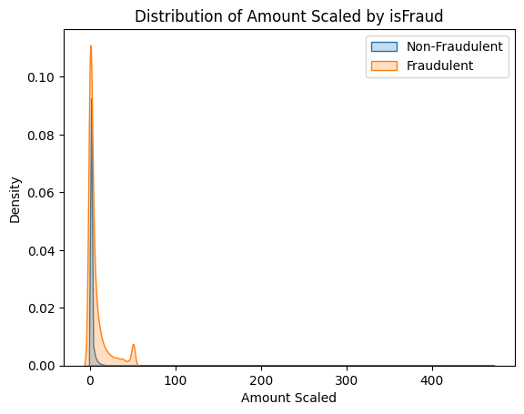

```python
import warnings
#suppress Future Warnings
warnings.simplefilter(action='ignore', category=FutureWarning)
#kde plot for non-fradulant transactions
sns.kdeplot(data=data[data['isFraud']==0]['amount_scaled'], label='Non-Fraudulent', shade=True)

#kde plot for fradualant transactions
sns.kdeplot(data=data[data['isFraud']==1]['amount_scaled'], label='Fraudulent', shade=True)

#add title and labels
plt.title('Distribution of Amount Scaled by isFraud')
plt.xlabel('Amount Scaled')
plt.ylabel('Density')
plt.legend()
plt.show()
```

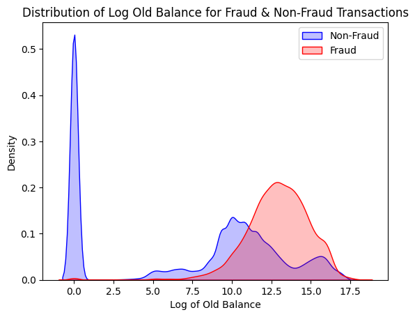

```python
import warnings

# Suppress FutureWarnings
warnings.simplefilter(action='ignore', category=FutureWarning)

# KDE plot for non-fraudulent transactions
sns.kdeplot(data=data[data['isFraud'] == 0],
            x='oldbalanceOrg_log', label='Non-Fraud', fill=True, color='blue')

# KDE plot for fraudulent transactions
sns.kdeplot(data=data[data['isFraud'] == 1],
            x='oldbalanceOrg_log', label='Fraud', fill=True, color='red')

# Add labels and title
plt.xlabel("Log of Old Balance")
plt.ylabel("Density")
plt.title("Distribution of Log Old Balance for Fraud & Non-Fraud Transactions")
plt.legend()
plt.show()
```

The Kernel Density Estimate (KDE) plot of the logarithmically transformed 'oldbalanceOrg' variable reveals a distinct pattern: fraudulent transactions are more frequently associated with accounts that possess higher initial balances. This observation implies a strategic tendency among fraudsters to target accounts holding significant funds, likely driven by the desire to maximize the potential financial gain from their illicit activities.

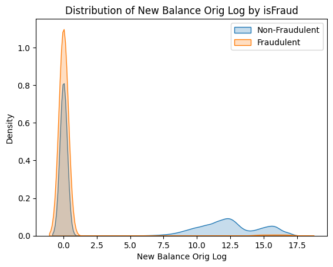

```python
#KDE plot for non-fradulent transactions with fill colors
sns.kdeplot(data=data[data['isFraud']==0]['newbalanceOrig_log'], label='Non-Fraudulent', shade=True)

#KDE plot for fraudulent transactions
sns.kdeplot(data=data[data['isFraud']==1]['newbalanceOrig_log'], label='Fraudulent', shade=True)

#Add title and labels
plt.title('Distribution of New Balance Orig Log by isFraud')
plt.xlabel('New Balance Orig Log')
plt.ylabel('Density')
plt.legend()
plt.show()
```

**Analyzing Receiver Accounts for Fraud Patterns**

To gain a more comprehensive understanding of fraudulent activities, the analysis will now extend to the receiver accounts, also known as destination accounts. The objective is to identify any distinct patterns or anomalies that differentiate these accounts in fraudulent transactions from those in legitimate ones. Particular attention will be paid to "flip patterns" or unusual behaviors, such as abrupt increases in account balances or other atypical transaction activity, which may serve as indicators of fraudulent fund transfers.

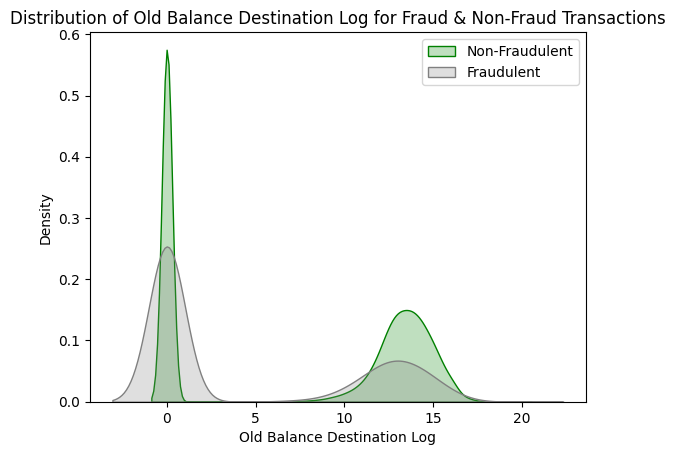

```python
#KDE plot for non-fraudulent transactions
sns.kdeplot(data=data[data['isFraud']==0], x='oldbalanceDest_log', label='Non-Fraudulent', fill=True, color='green')

# KDE plot for fraudulent transactions
sns.kdeplot(data=data[data['isFraud']==1], x='oldbalanceDest_log', label='Fraudulent', fill=True, color='grey')

# Add labels and title
plt.xlabel("Old Balance Destination Log")
plt.ylabel("Density")
plt.title("Distribution of Old Balance Destination Log for Fraud & Non-Fraud Transactions")
plt.legend()
plt.show()
```

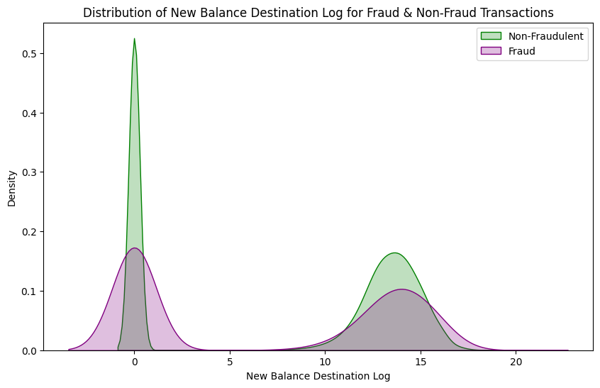

```python
#set figure size
plt.figure(figsize=(10, 6))

#KDE plot for non-fraudulent transactions
sns.kdeplot(data=data[data['isFraud']==0], x='newbalanceDest_log', label='Non-Fraudulent', fill=True, color='green')

# KDE plot for fraudulent transactions
sns.kdeplot(data=data[data['isFraud'] == 1],
            x='newbalanceDest_log', label='Fraud', fill=True, color='purple')

# Add labels and title
plt.xlabel("New Balance Destination Log")
plt.ylabel("Density")
plt.title("Distribution of New Balance Destination Log for Fraud & Non-Fraud Transactions")
plt.legend()
plt.show()
```

**5.Advanced Feature Engineering**

**Combining Weights for Enhanced Model Learning**

To sharpen the model's ability to identify the most critical fraudulent transactions, a combined weight column was created, integrating the weights derived from transaction type and transaction amount bins. This consolidated weighting strategy ensures that the model places a higher emphasis on learning from transactions exhibiting both high-risk characteristics: those of 'CASH_OUT' and 'TRANSFER' types, known for their susceptibility to fraud, and those involving substantial amounts, specifically within the 100,000+ and 1,000,000+ ranges. By prioritizing these high-risk combinations, the model's focus is optimized for effective fraud detection.

```python
#combine weights
data['combined_weight'] = data['transaction_type_weight'] * data['amount_bin_weight']
```

```python
from sklearn.impute import SimpleImputer

#initialize SimpleImputer with strategy = 'median'
imputer= SimpleImputer(strategy='median')
```

```python
#apply imputer to specific columns
data[['oldbalanceOrg', 'newbalanceOrig', 'oldbalanceDest',
      'newbalanceDest']] = imputer.fit_transform(data
       [['oldbalanceOrg', 'newbalanceOrig', 'oldbalanceDest',
         'newbalanceDest']])
```

**To better understand how balances change during transactions, I created two new features:**

```python
data['balance_diff_Org'] = data['oldbalanceOrg'] - data['newbalanceOrig']
data['balance_diff_Dest']= data['oldbalanceDest'] - data['newbalanceDest']
```

```python
data['balance_diff_Org_log'] = np.log1p(data['balance_diff_Org'])  # Log(x+1) for non-negative values
data['balance_diff_Dest_log'] = np.log1p(data['balance_diff_Dest'])
```

**Scaling Log-Transfored Features**

Following the logarithmic transformation of 'balance_diff_Org' and 'balance_diff_Dest', the RobustScaler technique was implemented to scale these features. Robust scaling was chosen due to its resilience to outliers, a critical consideration given the potential for extreme values in financial transaction data. Unlike standard scaling methods that rely on mean and standard deviation, RobustScaler utilizes the interquartile range (IQR), providing a more stable and reliable scaling process in the presence of outliers.

```python
# Replace infinite values with NaN to handle potential errors
data.replace([np.inf, -np.inf], np.nan, inplace=True)

# Define columns to scale (only those that exist)
columns_to_scale = [
    'balance_diff_Org_log',
    'balance_diff_Dest_log',
    'balance_diff_Org'
]

# Ensure all columns exist before scaling
columns_to_scale = [col for col in columns_to_scale if col in data.columns]

# Initialize RobustScaler
scaler = RobustScaler()

# Apply scaling only to existing columns
data[columns_to_scale] = scaler.fit_transform(data[columns_to_scale])

# Display the first few rows of scaled data
print("Scaling complete. First few rows of scaled data:")
print(data.head())
```

```
Scaling complete. First few rows of scaled data:
   step  type    amount     nameOrig  oldbalanceOrg  newbalanceOrig  \
0     1     1   9839.64  C1231006815       170136.0       160296.36
1     1     1   1864.28  C1666544295        21249.0        19384.72
2     1     3    181.00  C1305486145          181.0            0.00
3     1     0    181.00   C840083671          181.0            0.00
4     1     1  11668.14  C2048537720        41554.0        29885.86

      nameDest  oldbalanceDest  newbalanceDest  isFraud  ...  \
0  M1979787155             0.0             0.0        0  ...
1  M2044282225             0.0             0.0        0  ...
2   C553264065             0.0             0.0        1  ...
3    C38997010         21182.0             0.0        1  ...
4  M1230701703             0.0             0.0        0  ...

```

[output cut: 22 more lines]

**Why To Use Both?**

To prepare the data for modeling, a two-step preprocessing approach was employed. First, a logarithmic transformation was applied to address skewness, effectively bringing extreme values closer together and spreading out smaller values, thereby creating a more symmetrical distribution. Subsequently, RobustScaler was used to scale the log-transformed data. This scaling method, which utilizes the median and interquartile range (IQR), was selected to minimize the impact of outliers. The combined effect of these techniques results in a dataset that is both more normally distributed and less sensitive to extreme values, leading to enhanced model accuracy and stability.

**6. Final EDA and Visualization**

A scatter plot was generated to investigate the relationship between transaction amounts and the corresponding changes in the origin account's balance, represented by the 'balance_diff_Org' feature. This visual representation aims to reveal any distinctive patterns or anomalies that might differentiate fraudulent transactions from their legitimate counterparts, potentially highlighting key characteristics that contribute to fraud detection.

```python
data.columns
```

```
Index(['step', 'type', 'amount', 'nameOrig', 'oldbalanceOrg', 'newbalanceOrig',
       'nameDest', 'oldbalanceDest', 'newbalanceDest', 'isFraud',
       'isFlaggedFraud', 'transaction_type_weight', 'amount_scaled',
       'oldbalanceOrg_log', 'newbalanceOrig_log', 'oldbalanceDest_log',
       'newbalanceDest_log', 'amount_binned', 'amount_bin_weight',
       'combined_weight', 'balance_diff_Org', 'balance_diff_Dest',
       'balance_diff_Org_log', 'balance_diff_Dest_log'],
      dtype='object')
```

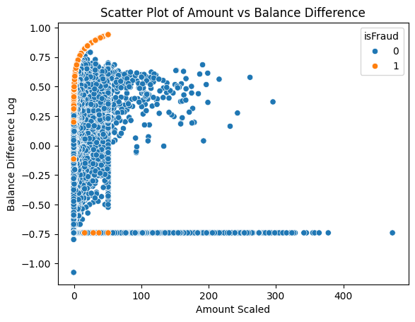

```python
#scatter plot of Amount vs Balance Difference
sns.scatterplot(x='amount_scaled', y='balance_diff_Org_log', data=data, hue='isFraud')
plt.title('Scatter Plot of Amount vs Balance Difference')
plt.xlabel('Amount Scaled')
plt.ylabel('Balance Difference Log')
plt.show()
```

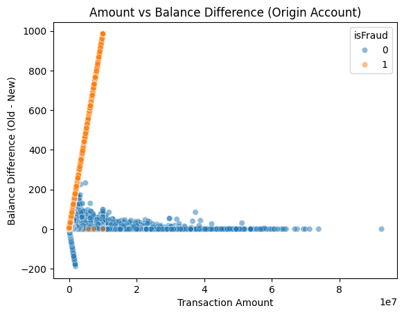

```python
# Scatter plot of Amount vs Balance Difference
sns.scatterplot(x='amount', y='balance_diff_Org', hue='isFraud', data=data, alpha=0.5)

# Add titles and labels
plt.title('Amount vs Balance Difference (Origin Account)')
plt.xlabel('Transaction Amount')
plt.ylabel('Balance Difference (Old - New)')
plt.show()
```

- Fraudulent transactions (isFraud = 1) involve the sender sending out large amounts of money, and the sender’s balance is decreasing (positive balance difference), often by a substantial amount.
- This indicates that fraudsters are using the sender’s account to send out large sums, depleting the balance, which aligns with typical fraud behavior like theft or unauthorized transfers.

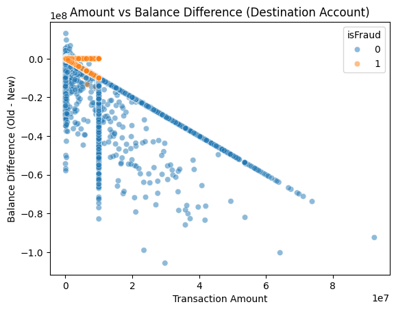

```python
#Scatter plot amount vs destination balance difference
sns.scatterplot(x='amount', y='balance_diff_Dest', hue='isFraud', data=data, alpha=0.5)

#Add title and label
plt.title('Amount vs Balance Difference (Destination Account)')
plt.xlabel('Transaction Amount')
plt.ylabel('Balance Difference (Old - New)')
plt.show()
```

```python
data.columns
```

```
Index(['step', 'type', 'amount', 'nameOrig', 'oldbalanceOrg', 'newbalanceOrig',
       'nameDest', 'oldbalanceDest', 'newbalanceDest', 'isFraud',
       'isFlaggedFraud', 'transaction_type_weight', 'amount_scaled',
       'oldbalanceOrg_log', 'newbalanceOrig_log', 'oldbalanceDest_log',
       'newbalanceDest_log', 'amount_binned', 'amount_bin_weight',
       'combined_weight', 'balance_diff_Org', 'balance_diff_Dest',
       'balance_diff_Org_log', 'balance_diff_Dest_log'],
      dtype='object')
```

- For legitimate transactions (blue, isFraud = 0), when the receiver gets money, their account balance usually increases (negative balance difference, e.g., -0.2 to -1.0), and larger amounts lead to bigger increases in their balance.
- For fraudulent transactions (orange, isFraud = 1), even though the receiver receives large amounts of money, their account balance doesn’t increase (balance difference near 0 or positive). This could mean the funds are immediately withdrawn, reversed, or never properly credited, indicating some kind of fraud like money laundering, theft, or account manipulation.

**7. Model Preparation**

**Preparing Data for Correlation Analysis**

For a more focused and effective correlation analysis, we removed unnecessary columns, streamlining the dataset to include only the transformed variables. This selective reduction simplifies the data, allowing us to concentrate on the most pertinent features for discerning meaningful relationships.

```python
# Drop irrelevant columns and original variables
columns_to_drop = ['step','amount', 'oldbalanceOrg', 'newbalanceOrig',
                   'newbalanceDest','oldbalanceDest','isFlaggedFraud',
                   'transaction_type_weight','amount_bin_weight','amount_binned',
                   'nameOrig','nameDest']
print(columns_to_drop)
```

```
['step', 'amount', 'oldbalanceOrg', 'newbalanceOrig', 'newbalanceDest', 'oldbalanceDest', 'isFlaggedFraud', 'transaction_type_weight', 'amount_bin_weight', 'amount_binned', 'nameOrig', 'nameDest']
```

```python
import pandas as pd

columns_to_drop = ['step', 'amount', 'oldbalanceOrg', 'newbalanceOrig', 'newbalanceDest', 'oldbalanceDest', 'isFlaggedFraud', 'transaction_type_weight', 'bin_weight', 'amount_bin', "nameOrig", "nameDest"]

existing_columns = [col for col in columns_to_drop if col in data.columns]

data = data.drop(columns=existing_columns)

print(data.head())
```

```
   type  isFraud  amount_scaled  oldbalanceOrg_log  newbalanceOrig_log  \
0     1        0      -0.332937          12.044359           11.984786
1     1        0      -0.373767           9.964112            9.872292
2     3        1      -0.382384           5.204007            0.000000
3     0        1      -0.382384           5.204007            0.000000
4     1        0      -0.323576          10.634773           10.305174

   oldbalanceDest_log  newbalanceDest_log amount_binned  amount_bin_weight  \
0            0.000000                 0.0        5K-10K                1.0
1            0.000000                 0.0         1K-5K                1.0
2            0.000000                 0.0       100-500                1.0
3            9.960954                 0.0       100-500                1.0
4            0.000000                 0.0       10K-50K                1.0

   combined_weight  balance_diff_Org  balance_diff_Dest  balance_diff_Org_log  \
0              1.0          0.969372                0.0              0.218701
1              1.0          0.183663                0.0              0.045421
2              2.0          0.017832                0.0             -0.197046
3              2.0          0.017832            21182.0             -0.197046
4              1.0          1.149510                0.0              0.236457

   balance_diff_Dest_log
0               0.000000
1               0.000000
2               0.000000
3               0.895468
4               0.000000
```

```python
data.head(30)
```

|  | type | isFraud | amount_scaled | oldbalanceOrg_log | newbalanceOrig_log | oldbalanceDest_log | newbalanceDest_log | amount_binned | amount_bin_weight | combined_weight | balance_diff_Org | balance_diff_Dest | balance_diff_Org_log | balance_diff_Dest_log |
| --- | --- | --- | --- | --- | --- | --- | --- | --- | --- | --- | --- | --- | --- | --- |
| 0 | 1 | 0 | -0.332937 | 12.044359 | 11.984786 | 0.000000 | 0.000000 | 5K-10K | 1.0 | 1.0 | 0.969372 | 0.00 | 0.218701 | 0.000000 |
| 1 | 1 | 0 | -0.373767 | 9.964112 | 9.872292 | 0.000000 | 0.000000 | 1K-5K | 1.0 | 1.0 | 0.183663 | 0.00 | 0.045421 | 0.000000 |
| 2 | 3 | 1 | -0.382384 | 5.204007 | 0.000000 | 0.000000 | 0.000000 | 100-500 | 1.0 | 2.0 | 0.017832 | 0.00 | -0.197046 | 0.000000 |
| 3 | 0 | 1 | -0.382384 | 5.204007 | 0.000000 | 9.960954 | 0.000000 | 100-500 | 1.0 | 2.0 | 0.017832 | 21182.00 | -0.197046 | 0.895468 |
| 4 | 1 | 0 | -0.323576 | 10.634773 | 10.305174 | 0.000000 | 0.000000 | 10K-50K | 1.0 | 1.0 | 1.149510 | 0.00 | 0.236457 | 0.000000 |
| 5 | 1 | 0 | -0.343288 | 10.894162 | 10.737337 | 0.000000 | 0.000000 | 5K-10K | 1.0 | 1.0 | 0.770177 | 0.00 | 0.194737 | 0.000000 |
| 6 | 1 | 0 | -0.346923 | 12.118312 | 12.078740 | 0.000000 | 0.000000 | 5K-10K | 1.0 | 1.0 | 0.700236 | 0.00 | 0.184819 | 0.000000 |
| 7 | 1 | 0 | -0.343063 | 12.078740 | 12.033067 | 0.000000 | 0.000000 | 5K-10K | 1.0 | 1.0 | 0.774505 | 0.00 | 0.195320 | 0.000000 |
| 8 | 1 | 0 | -0.362708 | 7.890583 | 0.000000 | 0.000000 | 0.000000 | 1K-5K | 1.0 | 1.0 | 0.263139 | 0.00 | 0.082869 | 0.000000 |
| 9 | 4 | 0 | -0.355984 | 10.638760 | 10.501863 | 10.643017 | 10.605341 | 5K-10K | 1.0 | 1.0 | 0.525861 | 1549.21 | 0.154986 | 0.660402 |
| 10 | 4 | 0 | -0.333934 | 8.404248 | 0.000000 | 9.291552 | 11.970243 | 5K-10K | 1.0 | 1.0 | 0.439878 | -147137.12 | 0.136388 | NaN |
| 11 | 1 | 0 | -0.367440 | 9.941361 | 9.779738 | 0.000000 | 0.000000 | 1K-5K | 1.0 | 1.0 | 0.305400 | 0.00 | 0.098381 | 0.000000 |
| 12 | 1 | 0 | -0.370201 | 8.531293 | 7.828142 | 0.000000 | 0.000000 | 1K-5K | 1.0 | 1.0 | 0.252276 | 0.00 | 0.078478 | 0.000000 |
| 13 | 1 | 0 | -0.323752 | 9.223059 | 0.000000 | 0.000000 | 0.000000 | 10K-50K | 1.0 | 1.0 | 0.997682 | 0.00 | 0.221699 | 0.000000 |
| 14 | 1 | 0 | -0.362327 | 13.128872 | 13.120694 | 0.000000 | 0.000000 | 1K-5K | 1.0 | 1.0 | 0.403800 | 0.00 | 0.127473 | 0.000000 |
| 15 | 0 | 0 | 0.789738 | 9.637306 | 0.000000 | 8.533854 | 10.849617 | 100K+ | 1.5 | 3.0 | 1.509773 | -46430.44 | 0.264860 | NaN |
| 16 | 1 | 0 | -0.375305 | 6.111467 | 0.000000 | 0.000000 | 0.000000 | 1K-5K | 1.0 | 1.0 | 0.044333 | 0.00 | -0.102497 | 0.000000 |
| 17 | 1 | 0 | -0.377383 | 9.959726 | 9.903445 | 0.000000 | 0.000000 | 1K-5K | 1.0 | 1.0 | 0.114069 | 0.00 | -0.004171 | 0.000000 |
| 18 | 1 | 0 | -0.379872 | 9.624038 | 9.578613 | 0.000000 | 0.000000 | 500-1K | 1.0 | 1.0 | 0.066168 | 0.00 | -0.060848 | 0.000000 |
| 19 | 3 | 0 | 0.718968 | 6.559615 | 0.000000 | 10.017976 | 0.000000 | 100K+ | 1.5 | 3.0 | 0.069454 | 22425.00 | -0.055805 | 0.900594 |
| 20 | 1 | 0 | -0.376279 | 9.536401 | 9.432008 | 0.000000 | 0.000000 | 1K-5K | 1.0 | 1.0 | 0.135306 | 0.00 | 0.013604 | 0.000000 |
| 21 | 4 | 0 | -0.335685 | 9.332558 | 7.599506 | 10.303370 | 9.734933 | 5K-10K | 1.0 | 1.0 | 0.916483 | 12935.30 | 0.212856 | 0.851133 |
| 22 | 4 | 0 | -0.377856 | 7.505492 | 6.623521 | 9.242904 | 0.000000 | 1K-5K | 1.0 | 1.0 | 0.104961 | 10330.00 | -0.012833 | 0.830916 |
| 23 | 1 | 0 | -0.363465 | 11.125099 | 11.066273 | 0.000000 | 0.000000 | 1K-5K | 1.0 | 1.0 | 0.381892 | 0.00 | 0.121663 | 0.000000 |
| 24 | 3 | 0 | 1.212361 | 9.290629 | 0.000000 | 8.743213 | 14.815839 | 100K+ | 1.5 | 3.0 | 1.067432 | -2712905.89 | 0.228740 | NaN |
| 25 | 1 | 0 | -0.352281 | 6.095825 | 0.000000 | 0.000000 | 0.000000 | 5K-10K | 1.0 | 1.0 | 0.043643 | 0.00 | -0.104127 | 0.000000 |
| 26 | 1 | 0 | -0.334786 | 11.665604 | 11.580739 | 0.000000 | 0.000000 | 5K-10K | 1.0 | 1.0 | 0.933783 | 0.00 | 0.214804 | 0.000000 |
| 27 | 1 | 0 | -0.342308 | 9.302828 | 7.992914 | 0.000000 | 0.000000 | 5K-10K | 1.0 | 1.0 | 0.789032 | 0.00 | 0.197256 | 0.000000 |
| 28 | 1 | 0 | -0.337737 | 7.992914 | 0.000000 | 0.000000 | 0.000000 | 5K-10K | 1.0 | 1.0 | 0.291503 | 0.00 | 0.093531 | 0.000000 |
| 29 | 1 | 0 | -0.332523 | 0.000000 | 0.000000 | 0.000000 | 0.000000 | 5K-10K | 1.0 | 1.0 | 0.000000 | 0.00 | -0.739252 | 0.000000 |

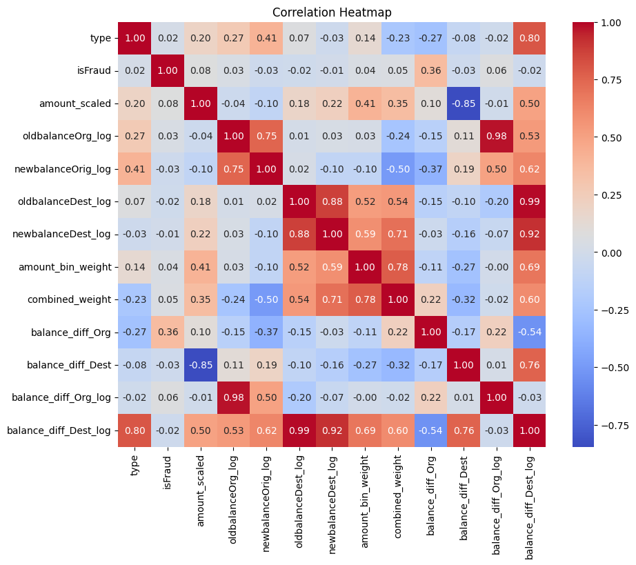

```python
import seaborn as sns
import matplotlib.pyplot as plt

#correlation matrix with datatypes and numner
correlation_matrix = data.select_dtypes(include=['number']).corr()

#plot
plt.figure(figsize=(10, 8))
sns.heatmap(correlation_matrix, annot=True, cmap='coolwarm', fmt=".2f")
plt.title('Correlation Heatmap')
plt.show()
```

**Dropping Highly Correlated Variables**

Following the generation of a heatmap to visualize correlations within the dataset, several variables were found to exhibit strong interdependencies. To mitigate the issue of multicollinearity, which can negatively impact model performance, and to streamline the dataset for subsequent analysis, specific columns were removed.

balance_diff_Dest balance_diff_Dest_log balance_diff_Org_log newbalanceDest_log Multicollinearity can negatively impact model performance by making it difficult to interpret the importance of individual features and by introducing redundancy.

```python
columns_to_drop = [ 'balance_diff_Dest','balance_diff_Dest_log','balance_diff_Org_log','newbalanceDest_log']


# Drop the specified columns
data = data.drop(columns=columns_to_drop)

# Check the updated DataFrame
print(data.head())
```

```
   type  isFraud  amount_scaled  oldbalanceOrg_log  newbalanceOrig_log  \
0     1        0      -0.332937          12.044359           11.984786
1     1        0      -0.373767           9.964112            9.872292
2     3        1      -0.382384           5.204007            0.000000
3     0        1      -0.382384           5.204007            0.000000
4     1        0      -0.323576          10.634773           10.305174

   oldbalanceDest_log amount_binned  amount_bin_weight  combined_weight  \
0            0.000000        5K-10K                1.0              1.0
1            0.000000         1K-5K                1.0              1.0
2            0.000000       100-500                1.0              2.0
3            9.960954       100-500                1.0              2.0
4            0.000000       10K-50K                1.0              1.0

   balance_diff_Org
0          0.969372
1          0.183663
2          0.017832
3          0.017832
4          1.149510
```

```python
data.columns
```

```
Index(['type', 'isFraud', 'amount_scaled', 'oldbalanceOrg_log',
       'newbalanceOrig_log', 'oldbalanceDest_log', 'amount_binned',
       'amount_bin_weight', 'combined_weight', 'balance_diff_Org'],
      dtype='object')
```

**Checking Multicollinearity Using Variance Inflation Factor (VIF)**

To verify the absence of harmful multicollinearity among the remaining numerical columns, we computed the Variance Inflation Factor (VIF) for each feature. The VIF measures the degree to which the variance of a regression coefficient is increased due to collinearity with other predictor variables. A VIF value exceeding 5 or 10 is commonly interpreted as a sign of significant multicollinearity, suggesting that the affected variables are strongly correlated and potentially redundant.

```python
from statsmodels.stats.outliers_influence import variance_inflation_factor

# Grab the numerical columns we want to check for multicollinearity
X = data[['amount_scaled', 'oldbalanceOrg_log', 'newbalanceOrig_log', 'oldbalanceDest_log', 'balance_diff_Org']]
```

```python
# Handle missing values (replace NaNs and Infs)
X = X.replace([np.inf, -np.inf], np.nan)
X = X.fillna(X.mean())

# Setup a DataFrame to store the VIF results
vif_data = pd.DataFrame()
vif_data["feature"] = X.columns

# Calculate VIF for each feature
vif_data["VIF"] = [variance_inflation_factor(X.values, i) for i in range(len(X.columns))]

# Show the VIF results
print(vif_data)
```

```
              feature       VIF
0       amount_scaled  1.090552
1   oldbalanceOrg_log  5.028138
2  newbalanceOrig_log  4.708820
3  oldbalanceDest_log  1.691036
4    balance_diff_Org  1.266884
```

**Dropping a Feature with High Multicollinearity**

```python
#list the columns we want to drop because it is too correlated with others
columns_to_drop=['oldbalanceOrg_log']

#drop the column from the dataset
data= data.drop(columns=columns_to_drop)

#take a quick look at the updated daataset to make sure the column is gone
print(data.head())
```

```
   type  isFraud  amount_scaled  newbalanceOrig_log  oldbalanceDest_log  \
0     1        0      -0.332937           11.984786            0.000000
1     1        0      -0.373767            9.872292            0.000000
2     3        1      -0.382384            0.000000            0.000000
3     0        1      -0.382384            0.000000            9.960954
4     1        0      -0.323576           10.305174            0.000000

  amount_binned  amount_bin_weight  combined_weight  balance_diff_Org
0        5K-10K                1.0              1.0          0.969372
1         1K-5K                1.0              1.0          0.183663
2       100-500                1.0              2.0          0.017832
3       100-500                1.0              2.0          0.017832
4       10K-50K                1.0              1.0          1.149510
```

```python
print(data.columns)
```

```
Index(['type', 'isFraud', 'amount_scaled', 'newbalanceOrig_log',
       'oldbalanceDest_log', 'amount_binned', 'amount_bin_weight',
       'combined_weight', 'balance_diff_Org'],
      dtype='object')
```

```python
data
```

|  | type | isFraud | amount_scaled | newbalanceOrig_log | oldbalanceDest_log | amount_binned | amount_bin_weight | combined_weight | balance_diff_Org |
| --- | --- | --- | --- | --- | --- | --- | --- | --- | --- |
| 0 | 1 | 0 | -0.332937 | 11.984786 | 0.000000 | 5K-10K | 1.0 | 1.0 | 0.969372 |
| 1 | 1 | 0 | -0.373767 | 9.872292 | 0.000000 | 1K-5K | 1.0 | 1.0 | 0.183663 |
| 2 | 3 | 1 | -0.382384 | 0.000000 | 0.000000 | 100-500 | 1.0 | 2.0 | 0.017832 |
| 3 | 0 | 1 | -0.382384 | 0.000000 | 9.960954 | 100-500 | 1.0 | 2.0 | 0.017832 |
| 4 | 1 | 0 | -0.323576 | 10.305174 | 0.000000 | 10K-50K | 1.0 | 1.0 | 1.149510 |
| ... | ... | ... | ... | ... | ... | ... | ... | ... | ... |
| 6362615 | 0 | 1 | 1.355688 | 0.000000 | 0.000000 | 100K+ | 1.5 | 3.0 | 33.464464 |
| 6362616 | 3 | 1 | 31.927868 | 0.000000 | 0.000000 | 1000K+ | 2.0 | 4.0 | 621.781102 |
| 6362617 | 0 | 1 | 31.927868 | 0.000000 | 11.134441 | 1000K+ | 2.0 | 4.0 | 621.781102 |
| 6362618 | 3 | 1 | 3.968266 | 0.000000 | 0.000000 | 100K+ | 1.5 | 3.0 | 83.739697 |
| 6362619 | 0 | 1 | 3.968266 | 0.000000 | 15.688865 | 100K+ | 1.5 | 3.0 | 83.739697 |

6362604 rows × 9 columns

**8. Model Building and Evaluation**

```python
# Import necessary libraries
from sklearn.metrics import classification_report, accuracy_score, confusion_matrix
from sklearn.model_selection import train_test_split
from sklearn.linear_model import SGDClassifier  # Using SGDClassifier for faster training
from imblearn.over_sampling import SMOTE
from imblearn.under_sampling import RandomUnderSampler
import numpy as np
import pandas as pd

# Separate features (X) and target (y), but keep 'combined_weight' for now
X = data.drop(columns=['isFraud'])  # Features (excluding the target)
y = data['isFraud']  # Target variable

# 1. Check for NaNs in y
print("NaNs in y before handling:", y.isna().sum())

# 2. Handle NaNs in y (remove rows with NaN in y)
nan_indices = y.isna()
X = X[~nan_indices]
y = y[~nan_indices]

# Downsample the majority class to reduce dataset size (optional, adjust sampling_strategy)
rus = RandomUnderSampler(sampling_strategy=0.1, random_state=42)  # Keep 10% of the majority class
X_under, y_under = rus.fit_resample(X, y)

# Handle string values in X_under before SMOTE
def convert_range_to_average(value):
    if isinstance(value, str) and '-' in value:
        try:
            lower, upper = map(float, value.split('-'))
            return (lower + upper) / 2
        except ValueError:
            return np.nan  # Handle bad data.
    else:
        try:
            return float(value)  # Convert to float if not a string range.
        except ValueError:
            return np.nan  # Handle bad data.

for col in X_under.columns:
    if X_under[col].dtype == 'object':
        X_under[col] = X_under[col].apply(convert_range_to_average)

# Handle categorical and NaN values.
for col in X_under.columns:
    if X_under[col].dtype == 'category':
        # Handle categorical columns (example: one-hot encoding)
        X_under = pd.get_dummies(X_under, columns=[col], dummy_na=True) #add dummy_na=True to handle nan values.
    else:
        # Handle NaN values for numerical columns
        X_under[col] = X_under[col].fillna(X_under[col].mean())

# Apply SMOTE to balance classes (optimized with k_neighbors=1 for speed)
smote = SMOTE(sampling_strategy=0.5, k_neighbors=1, random_state=42)  # Balance classes
X_resampled, y_resampled = smote.fit_resample(X_under, y_under)

# Separate 'combined_weight' from the features
combined_weight_resampled = X_resampled['combined_weight']  # Extract sample weights
X_resampled = X_resampled.drop(columns=['combined_weight'])  # Drop weights from features

# Convert to NumPy arrays for faster processing
X_resampled, y_resampled = X_resampled.values, y_resampled.values

# Single stratified train-test split
X_train, X_test, y_train, y_test, weights_train, weights_test = train_test_split(
    X_resampled, y_resampled, combined_weight_resampled,
    test_size=0.2,  # 20% for testing
    stratify=y_resampled,  # Preserve class balance
    random_state=42  # For reproducibility
)

# Define a faster model (SGDClassifier with log loss for logistic regression)
model = SGDClassifier(
    loss='log_loss',  # Equivalent to logistic regression
    penalty='l1',  # L1 regularization for feature selection
    alpha=0.0001,  # Regularization strength
    max_iter=1000,  # Maximum iterations
    tol=1e-3,  # Tolerance for stopping
    random_state=42,  # For reproducibility
    n_jobs=-1  # Use all CPU cores for faster training
)

# Train the model with sample weights
model.fit(X_train, y_train, sample_weight=weights_train)

# Make predictions on the test set
y_pred = model.predict(X_test)

# Evaluate the model
accuracy = accuracy_score(y_test, y_pred)  # Calculate accuracy
report = classification_report(y_test, y_pred)  # Generate classification report
conf_matrix = confusion_matrix(y_test, y_pred)  # Generate confusion matrix

# Print results
print(f" Accuracy: {accuracy:.4f}")
print("\n Classification Report:\n", report)
print("\n Confusion Matrix:\n", conf_matrix)
```

```
NaNs in y before handling: 0
 Accuracy: 0.9559

 Classification Report:
               precision    recall  f1-score   support

           0       0.96      0.97      0.97     16394
           1       0.94      0.93      0.93      8197

    accuracy                           0.96     24591
   macro avg       0.95      0.95      0.95     24591
weighted avg       0.96      0.96      0.96     24591


 Confusion Matrix:
 [[15922   472]
 [  612  7585]]
```

```python
# Training set predictions
y_train_pred = model.predict(X_train)
train_accuracy = accuracy_score(y_train, y_train_pred)
train_report = classification_report(y_train, y_train_pred)
print(f"Training Accuracy: {train_accuracy:.4f}")
print("Training Report:\n", train_report)
```

```
Training Accuracy: 0.9562
Training Report:
               precision    recall  f1-score   support

           0       0.96      0.97      0.97     65576
           1       0.94      0.92      0.93     32788

    accuracy                           0.96     98364
   macro avg       0.95      0.95      0.95     98364
weighted avg       0.96      0.96      0.96     98364
```

```python
from sklearn.model_selection import train_test_split
from sklearn.preprocessing import StandardScaler
from sklearn.ensemble import RandomForestClassifier
from sklearn.metrics import accuracy_score, precision_score, recall_score, f1_score, confusion_matrix, classification_report
from scipy.stats import ttest_ind
```

```python
# Model Training
print("Training Random Forest Model...")
model = RandomForestClassifier(n_estimators=100, random_state=42)
model.fit(X_train, y_train)
```

```
Training Random Forest Model...
```

```
RandomForestClassifier(random_state=42)
```

```python
# Predictions
y_pred = model.predict(X_test)
```

```python
# Model Evaluation
print("Evaluating model...")
accuracy = accuracy_score(y_test, y_pred)
precision = precision_score(y_test, y_pred)
recall = recall_score(y_test, y_pred)
f1 = f1_score(y_test, y_pred)
conf_matrix = confusion_matrix(y_test, y_pred)
```

```
Evaluating model...
```

```python
print(f"Accuracy: {accuracy:.4f}")
print(f"Precision: {precision:.4f}")
print(f"Recall: {recall:.4f}")
print(f"F1-score: {f1:.4f}")
print("Confusion Matrix:\n", conf_matrix)
print("Classification Report:\n", classification_report(y_test, y_pred))
```

```
Accuracy: 0.9978
Precision: 0.9949
Recall: 0.9985
F1-score: 0.9967
Confusion Matrix:
 [[16352    42]
 [   12  8185]]
Classification Report:
               precision    recall  f1-score   support

           0       1.00      1.00      1.00     16394
           1       0.99      1.00      1.00      8197

    accuracy                           1.00     24591
   macro avg       1.00      1.00      1.00     24591
weighted avg       1.00      1.00      1.00     24591
```

Performing the A/B testingon this model

```python
# A/B Testing - Performance Comparison Between Two Models
print("Performing A/B Testing...")
model_b = RandomForestClassifier(n_estimators=50, random_state=42)  # Alternative model
model_b.fit(X_train, y_train)
y_pred_b = model_b.predict(X_test)

accuracy_b = accuracy_score(y_test, y_pred_b)
f1_b = f1_score(y_test, y_pred_b)
```

```
Performing A/B Testing...
```

```python
# T-test for statistical significance
t_stat, p_value = ttest_ind(y_pred, y_pred_b)
print(f"Model A Accuracy: {accuracy:.4f}, F1-score: {f1:.4f}")
print(f"Model B Accuracy: {accuracy_b:.4f}, F1-score: {f1_b:.4f}")
print(f"T-test statistic: {t_stat:.4f}, P-value: {p_value:.4f}")

if p_value < 0.05:
    print("Statistically significant difference found.")
else:
    print("No significant difference between models.")
```

```
Model A Accuracy: 0.9978, F1-score: 0.9967
Model B Accuracy: 0.9980, F1-score: 0.9970
T-test statistic: 0.0382, P-value: 0.9695
No significant difference between models.
```

**Visualize Results**

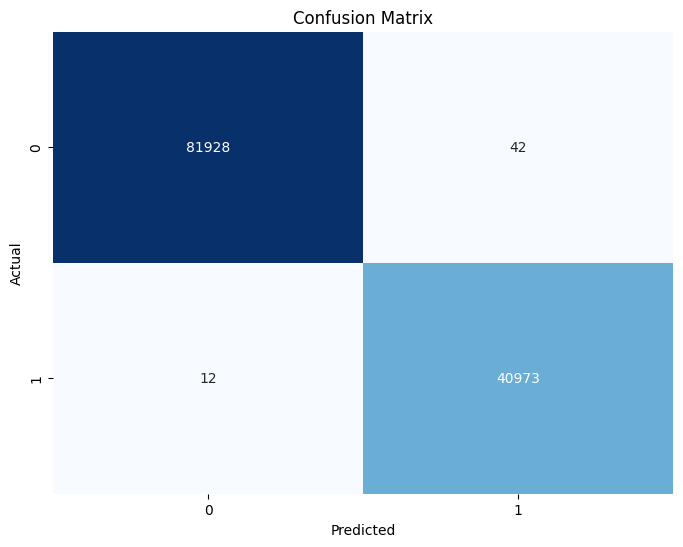

```python
from sklearn.metrics import confusion_matrix

y_pred_all = model.predict(X_resampled)

cm = confusion_matrix(y_resampled, y_pred_all)

plt.figure(figsize=(8, 6))
sns.heatmap(cm, annot=True, fmt='d', cmap='Blues', cbar=False)
plt.title('Confusion Matrix')
plt.xlabel('Predicted')
plt.ylabel('Actual')
plt.show()
```

***ROC Curve***

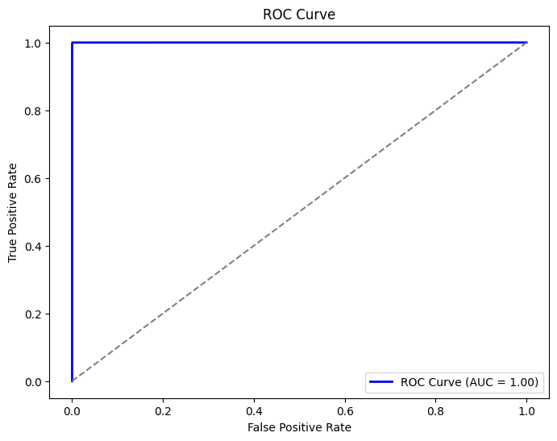

```python
from sklearn.metrics import roc_curve, auc

y_pred_proba = model.predict_proba(X_resampled)[:, 1]

fpr, tpr, thresholds = roc_curve(y_resampled, y_pred_proba)
roc_auc = auc(fpr, tpr)

plt.figure(figsize=(8, 6))
plt.plot(fpr, tpr, color='blue', lw=2, label=f'ROC Curve (AUC = {roc_auc:.2f})')
plt.plot([0, 1], [0, 1], color='gray', linestyle='--')
plt.xlabel('False Positive Rate')
plt.ylabel('True Positive Rate')
plt.title('ROC Curve')
plt.legend(loc='lower right')
plt.show()
```

**Final Note that is on Model Selection and Feature Engineering**

While working on this project, I did experiment with 8-9 different features in engineering techniques and tried multiple models, that includes *XGBoost and Random Forest*.